# ECON 713A - Problem Set 3

Alex von Hafften[^1]

3/6/2020

## 1 Paying Your TA as a Public Good

$N$ identical first year students have an upcoming final in their micro class with Lones. Students can contribute money towards a common pool to be used to pay the TA for a review session. The TA requires at least $M > 1$ dollars to run the review session. Each student’s utility is $U = aI + m$, where $I = 1$ if the review session is provided and equals 0 otherwise and $m$ is the amount of money each student consumes. What is the minimum $N$ for which it is efficient for the review session to be provided?

Say each student is endowed with $\bar{m}$ dollars. Since the students are identical, each student contributes the same amount, namely $M/N$ dollars. Thus, the student utility without the review session is $U_0 = \bar{m}$ and each student's utility with the review session is $U_1 = a + \bar{m} - M/N$. For the review session to be efficient, a representative student need to be weakly better off:

$$U_1 \ge U_0 \implies a + \bar{m} - M/N \ge \bar{m} \implies N \ge M/a$$

Thus, the minimum $N$ for a review session to be efficient is $M/a$.

## 2 Efficient Peak Load Pricing

Assume peak and off-peak periods in the public transport in Madison. Half the day is peak, when the inverse demand for bus tickets is $p_H = H - x_H$, and half is off peak when the inverse demand for bus tickets is $p_L = L - x_L$, with $H > L$. Each demand is expressed in dollars and assume fractions of a ticket can be bought. One ticket requires paying the bus driver and gas among other things, costing $b$ dollars per ticket (operating costs). In addition, there is a capacity cost (parking) per day equal to $\beta$. The cost of a given capacity is the same whether it is used at peak times only or off-peak also. What is the welfare maximizing pricing scheme $(p_H^*,p_L^*)$? Show graphically that there are no gains from charging higher prices than $(p_H^*,p_L^*)$.

Consumer surplus is $CS(x_L, x_H) = x_L^2/2 + x_H^2/2$. Producer surplus for the capacity $\bar{x} \ge x_L, x_H$ is $PS(x_L, x_H) = (H - b - x_H)x_H + (H - b - x_L)x_L - \beta \bar{x}$. The Lagrangian:

$$\begin{align*}
\Lf
&= CS(x_L, x_H) + PS(x_L, x_H) + \lambda_H (\bar{x} - x_H) + \lambda_L (\bar{x} - x_L)\\
&= [x_L^2/2 + x_H^2/2] + [(H - b - x_H)x_H + (H - b - x_L)x_L - \beta \bar{x}] + \lambda_H (\bar{x} - x_H) + \lambda_L (\bar{x} - x_L)
\end{align*}$$

Kuhn-Tucker conditions:

$$\begin{align*}
H - b - x_H &= \lambda_H & [x_H] \\
L - b - x_L &= \lambda_L & [x_L] \\
\lambda_H + \lambda_L &= \beta & [\bar{x}] \\
\lambda_H(\bar{x} - x_H) &= 0, x_H \le \bar{x}, \lambda_H \ge 0 & [\lambda_H] \\
\lambda_L(\bar{x} - x_L) &= 0, x_L \le \bar{x}, \lambda_L \ge 0 & [\lambda_L] \\
\end{align*}$$

Notice that $x_H = \bar{x}$.

Case 1: $x_L < \bar{x} \implies \lambda_L = 0 \implies \lambda_H = \beta \implies x_H = H - b - \beta$

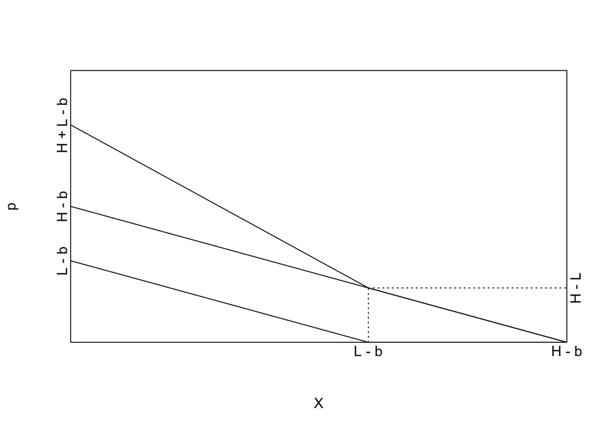

## 3 The Exchange Economy in the Edgeworth Box, Encore

Consider an intertemporal problem in which there are only two commodities people can consume: corn today $(c_1)$ and corn next period $(c_2)$. There are two consumers: Consumer $A$ who has utility function $U^A(c_1,c_2) = c_1c_2$, and Consumer $B$ who has utility function $U^B(c_1,c_2) = \min\{c_1,c_2\}$. Consumer $A$ is endowed with no units of $c_1$ and 100 units $c_2$, while Consumer $B$ is endowed with 200 units of $c_1$ and no units of $c_2$.

1. Draw the Edgeworth box that corresponds to this situation with consumer $A$ in the lower left, and where the horizontal distance from the lower left origin represents $A$'s allocation of $c_1$. Label the endowment in this box.
2. Sketch the contract curve in this box.
3. Solve for the equilibrium interest rate, and the amounts consumed by each consumer in equilibrium. Illustrate the equilibrium budget constraint and consumption point in your diagram.

The endowment is the red point, the contract curve is the blue line, and the price line is the black line.

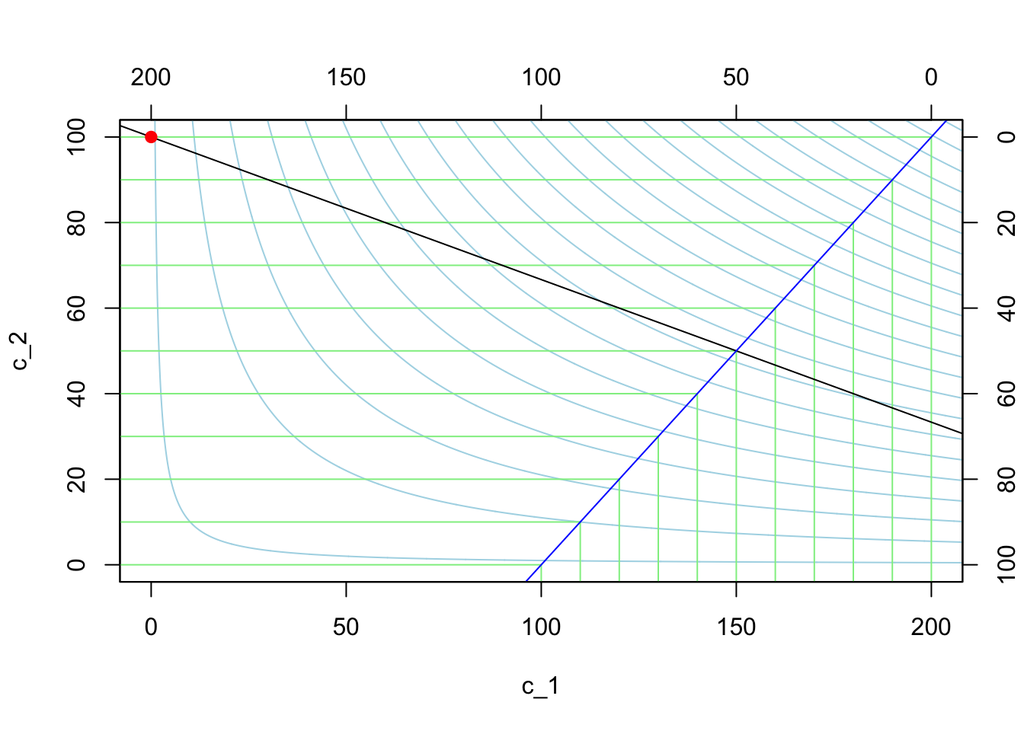

For the contract curve, with consumer $B$'s Leontif preferences, we know that $c_1^B = c_2^B = c^B$. Furthermore, this implies that $c_1^A = c_2^A + 100$. Consumer $A$ equates their marginal rate of substitution to the price ratio:

$$\frac{p_1}{p_2}= \frac{U^A_1}{U^A_2} = \frac{c_2^A}{c_1^A}=\frac{c_1^A - 100}{c_1^A}$$
For each consumer, the value of their endowment is equal to the value of their consumption:

$$\begin{align*}
p_1 c_1^A + p_2 c_2^A &= 100 p_2 \\
\implies
\frac{p_1}{p_2}c_1^A + c_2^A &=100\\
\implies
\Bigg(\frac{c_1^A - 100}{c_1^A}\Bigg)c_1^A + (c_1^A - 100) &=100 \\
\implies
c_1^A &=150 \\
\implies
c_2^A &=50 \\
\implies
c^B &=50
\end{align*}$$

The gross interest rate is $i = \frac{p_2}{p_1} = \frac{c_1^A}{c_2^A} = 3$.

## 4 The Exchange Economy in the Edgeworth Box

There are two consumers: Consumer $A$ who has utility function $U^A(x,y) = xy$, and Consumer $B$ who has utility function $U^B(x, y) = y + 20 log x$. Consumer $A$ is endowed with 30 units of $x$ and no units of $y$, while Consumer $B$ is endowed with no units of $x$ and 20 units of $y$.

1. Draw the Edgeworth box that corresponds to this situation with consumer $A$ in the lower left, and where the horizontal distance from the lower left origin represents $A$'s allocation of $x$. Label the endowment in this box.

2. Solve for the equation that describes the contract curve, and sketch the curve in your Edgeworth box.

3. Solve for the equilibrium price ratio, and the amounts consumed by each consumer in equilibrium. Illustrate the equilibrium budget constraint and consumption point in your diagram.

[^1]: I worked on this problem set with a study group of Michael Nattinger, Andrew Smith, and Ryan Mather. I also discussed problems with Sarah Bass, Emily Case, Danny Edgel, and Katherine Kwok.